# Excess Antibiotics Before Cocci

This document summarizes estimates for unecessary antibiotics recieved before a diagnosis of coccidioidomycosis.

The following plot depicts counts of the number of perscriptions each week before diagnosis, for each of the relevant antibiotic types

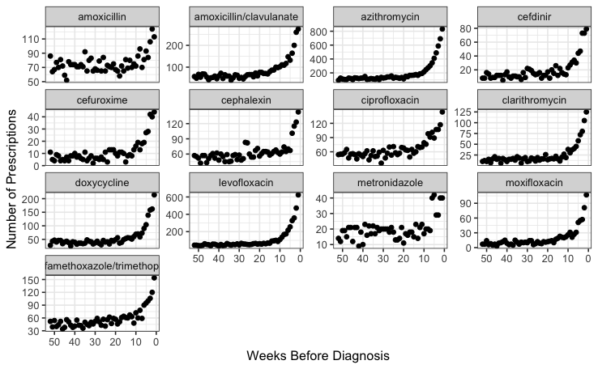

The following plot depicts expected trends for the number of antibiotics received based on data 14-52 weeks prior to diagnosis, using linear, quadratic and cubic trends.

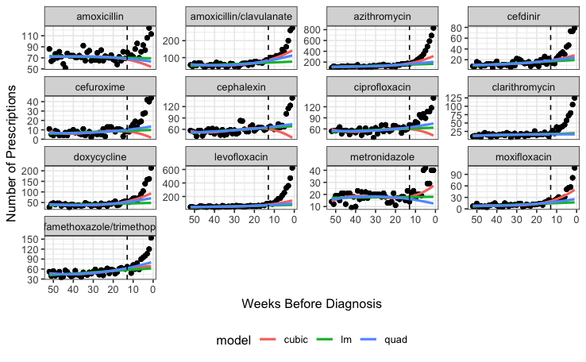

The following plots depicts the number of antibiotics estimated to be in excess based on the expected trends depicted above.

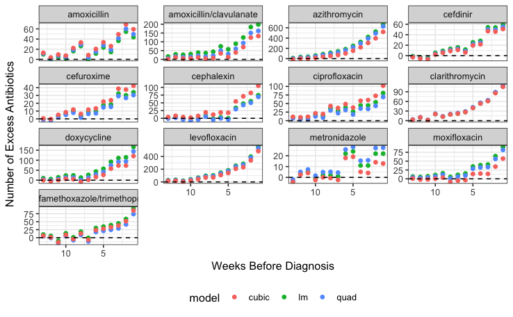

## Bootstrapping results

To estimate the number of excess antibiotics while accounting for uncertainty in the expected trend we utilized the following bootstrapping approach

1. Draw a bootstrapped sample of patients
2. Calculate the number of antibiotics each week
3. Estimate expected trends over the 14-52 weeks prior to diagnosis for each trend type
4. Compute the excess number of antibiotics as the difference between the observed number of antibiotics and the expected trend (extrapolated to the period between 1-13 weeks prior to diagnosis)

The above procedure was repeated 1000 times.

### Linear Models

The following figure summarizes expected trends for the number of antibiotics based on a linear model. The blue line depicts the mean trend across models and the gray band depicts a 95% confidence band.

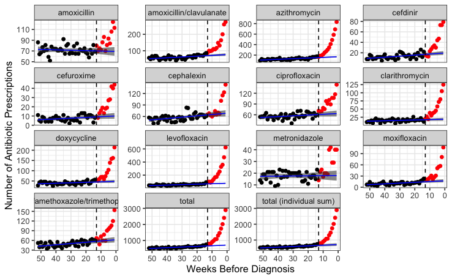

### Quadratic Models

The following figure summarizes expected trends for the number of antibiotics based on a quadratic model. The blue line depicts the mean trend across models and the gray band depicts a 95% confidence band.

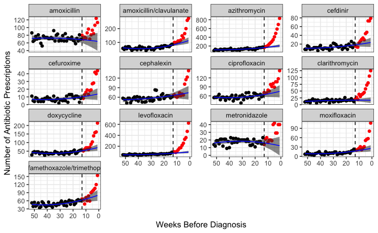

### Cubic Models

The following figure summarizes expected trends for the number of antibiotics based on a cubic model. The blue line depicts the mean trend across models and the gray band depicts a 95% confidence band.

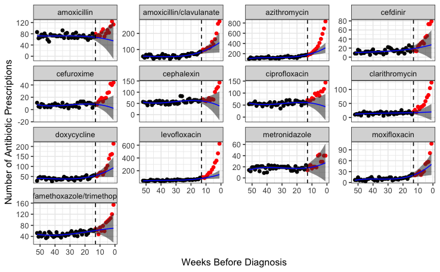

### Excess Antibiotics by Week

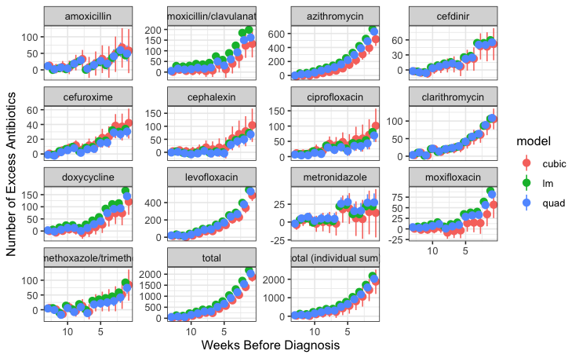

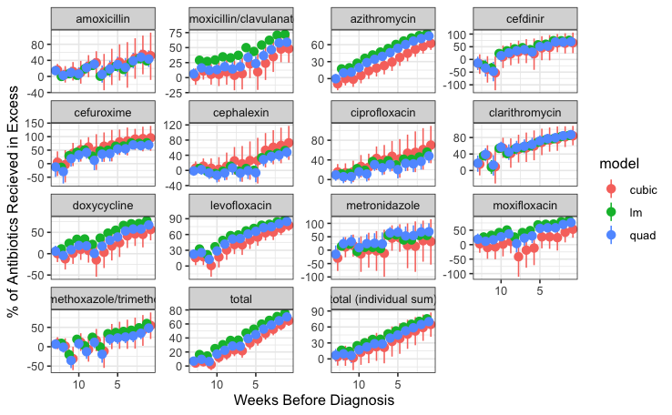

### Aggregate Number of Excess Antibiotics Before Diagnosis

The following table depicts the total number of excess antibiotics recieved by antibiotic and model type:

| abx | lm | quad | cubic |
| --- | --- | --- | --- |
| amoxicillin | 244.62 (156.56, 332.11) | 287.07 (94.8, 494.1) | 347.88 (-110.77, 794.28) |
| amoxicillin/clavulanate | 947.77 (860.04, 1031.41) | 650.2 (443.89, 833.79) | 457.41 (21.06, 887.89) |
| azithromycin | 2849.06 (2709.8, 2982.31) | 2542.12 (2254.79, 2827.97) | 1837.41 (1171.31, 2525.59) |
| cefdinir | 266.84 (225.98, 306.67) | 232.17 (137.46, 322.83) | 209.35 (-19.4, 428.95) |
| cefuroxime | 172.59 (135.29, 205.84) | 143.44 (75.83, 210.05) | 218.76 (71.61, 351.37) |
| cephalexin | 218.54 (128.37, 306.61) | 169.76 (-19.57, 361.57) | 398.87 (-39.95, 834.71) |
| ciprofloxacin | 412.2 (320.66, 502.58) | 319.25 (137.45, 494.39) | 525.67 (151.09, 916.68) |
| clarithromycin | 463.36 (415.15, 510.84) | 482.38 (391.66, 570.93) | 460.49 (264.01, 668.97) |
| doxycycline | 701.17 (619.31, 775.33) | 517.01 (350.98, 672.73) | 368.66 (-9.9, 696.86) |
| levofloxacin | 2195.89 (2108.67, 2282.21) | 2038.96 (1842.95, 2235.41) | 1740.71 (1276.16, 2182.03) |
| metronidazole | 121.47 (72.65, 168.74) | 166.1 (67.47, 274.61) | 70.86 (-168.34, 304.6) |
| moxifloxacin | 345.22 (295.02, 389.19) | 276.63 (182.31, 364.87) | 117.4 (-107.5, 322.51) |
| sulfamethoxazole/trimethoprim | 339.8 (245.61, 433.46) | 191.75 (19.61, 367.41) | 258.96 (-104.59, 622.73) |
| total | 9279.75 (8938.79, 9610.45) | 8018.23 (7319.85, 8693.25) | 7016.11 (5510.78, 8433.27) |
| total (individual sum) | 9278.52 (8293.11, 10227.31) | 8016.85 (5979.63, 10030.67) | 7012.43 (2394.78, 11537.15) |

## Patients Metrics for Reciept of Unecessary Antibiotics

In order to estimate the number of patients who recieved an unecessary antibiotic we performed the following bootstrapping-based analysis:

1. Estimate the expected trend based on a bootstrapped sample of patients, and compute the estimated number of excess antibiotics (as described above).
2. Return to the aggregate sample of patients; each week draw the estimated number of excess antibiotics by antibiotic type.
3. Compute corresponding metrics and aggregate across trials.

| metric | lm | quad | cubic |
| --- | --- | --- | --- |
| Number of Patients with Excess Antibiotic | 6819.122 (6640.925, 6998) | 6160.591 (5781, 6531.05) | 5622.667 (4778.625, 6395.075) |
| % of Patients with Excess Antibiotic | 25.35 (24.68, 26.01) | 22.9 (21.49, 24.27) | 20.9 (17.76, 23.77) |
| Excess Antibiotics per patient (all patients) | 0.347 (0.335, 0.347) | 0.302 (0.278, 0.302) | 0.268 (0.22, 0.268) |
| Excess Antibiotics per patient (patients w/ excess) | 1.367 (1.351, 1.367) | 1.319 (1.294, 1.319) | 1.283 (1.236, 1.283) |

The following table depicts the fraction of patients who recieved an unecessary antibiotic by type:

| name | lm | quad | cubic |
| --- | --- | --- | --- |
| amoxicillin | 0.9 (0.64, 1.21) | 1.06 (0.46, 1.76) | 1.3 (0.07, 2.72) |
| amoxicillin/clavulanate | 3.33 (3.04, 3.59) | 2.33 (1.63, 2.95) | 1.72 (0.57, 3.15) |
| azithromycin | 9.93 (9.49, 10.36) | 8.94 (8.04, 9.84) | 6.66 (4.63, 8.88) |
| cefdinir | 0.98 (0.86, 1.09) | 0.87 (0.6, 1.13) | 0.81 (0.21, 1.45) |
| cefuroxime | 0.61 (0.5, 0.72) | 0.52 (0.32, 0.72) | 0.73 (0.32, 0.94) |
| cephalexin | 0.84 (0.66, 1.1) | 0.75 (0.41, 1.29) | 1.44 (0.33, 2.65) |
| ciprofloxacin | 1.46 (1.15, 1.77) | 1.14 (0.56, 1.72) | 1.82 (0.59, 2.98) |
| clarithromycin | 1.61 (1.46, 1.76) | 1.67 (1.39, 1.96) | 1.6 (0.99, 2.17) |
| doxycycline | 2.46 (2.19, 2.69) | 1.87 (1.38, 2.37) | 1.43 (0.51, 2.44) |
| levofloxacin | 7.4 (7.11, 7.66) | 6.92 (6.31, 7.51) | 6 (4.56, 7.37) |
| metronidazole | 0.45 (0.32, 0.59) | 0.58 (0.3, 0.91) | 0.36 (0.02, 0.96) |
| moxifloxacin | 1.2 (1.03, 1.35) | 0.98 (0.69, 1.26) | 0.54 (0.12, 1.12) |
| sulfamethoxazole/trimethoprim | 1.23 (0.98, 1.5) | 0.83 (0.4, 1.3) | 1.03 (0.14, 2.07) |

The following table depicts the distribution in the number of unecessary antibiotics individuals recieved:

| n_excess | lm | quad | cubic |
| --- | --- | --- | --- |
| 0 | 20085.88 (19907, 20264.08) | 20744.41 (20373.95, 21124) | 21282.33 (20509.92, 22126.38) |
| 1 | 4847.22 (4734.97, 4967) | 4565.92 (4352.9, 4767.1) | 4311.25 (3813.93, 4713.08) |
| 2 | 1542.48 (1460.98, 1619.03) | 1283.94 (1154, 1416.03) | 1069.59 (803.95, 1337.02) |
| 3 | 346.34 (307, 384.02) | 256.96 (206, 310) | 201.84 (126, 291) |
| 4 | 66.56 (52, 83) | 44.81 (30, 61.02) | 33.84 (15, 56) |
| 5 | 12.99 (7, 20) | 7.48 (3, 13) | 5.37 (1, 12) |
| 6 | 2.83 (0, 6) | 1.27 (0, 4) | 0.72 (0, 3) |
| 7 | 0.51 (0, 2) | 0.17 (0, 1) | 0.05 (0, 1) |
| 8 | 0.14 (0, 1) | 0.04 (0, 1) | 0 (0, 0) |
| 9 | 0.04 (0, 1) | 0 (0, 0) | 0 (0, 0) |
| 10 | 0.01 (0, 0) | 0 (0, 0) | 0 (0, 0) |